# 高等教育配對機制的探討： 一個特色大學的招生和學生與科系配對結果的研究

蔡彣涓

# 摘要

2002 年「大學多元入學方案」的實施主要為高等教育的入學制 度引進不同的篩選方式。有鑑於此，本文使用世新大學 2005 學年度 至 2015 學年度的校務資料與 2005 學年度至 2014 學年度個人申請、 繁星推薦和大學考試入學分發招生簡章的校系分則之串連資料，研 究大學多元入學管道的配對規則（學生與校系的配對邏輯）與招生 標準（大學校系對學生的偏好排序基礎）對學生於大學前 4 個學期 的標準化成績與其系、校續讀機率的影響。由於世新大學為一以新 聞傳播著稱的特色大學，故本文主要係利用該特質解決校務研究普 遍缺乏學生志願序資料的問題。實證結果顯示在控制世新大學各系 組所設定的招生標準下，個人申請與繁星推薦入學的制度將較考試 分發更能招收到成績表現較佳、但同時亦有較高的風險會轉至新聞 傳播學院相關系組的學生。另外，大學校系若以英文成績做為招生 標準，則學生將有較高的可能性以轉系（尤其是轉至新聞傳播學院 相關系組）的方式解決其與入學系組配適錯誤的問題。 關鍵詞：高等教育、配對、招生、續讀率 JEL 分類代號：C78, I23, I28

# 1. 前言

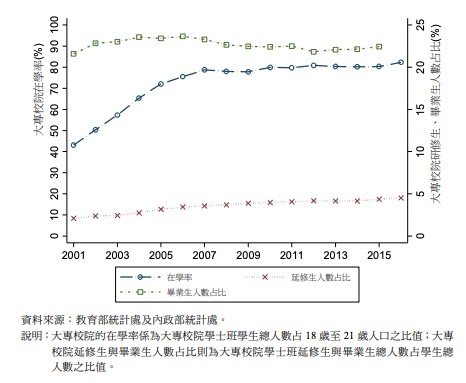

圖一

# 資料來源：教育部統計處及內政部統計處。

校院延修生與畢業生人數占比則為大專校院學士班延修生與畢業生總人數占學生總 人數之比值。 圖 1 歷年大專校院學士班的在學率與延修生和畢業生人數占比